## Presenting Crosstabber

### A simple to use web application for analyzing real world data

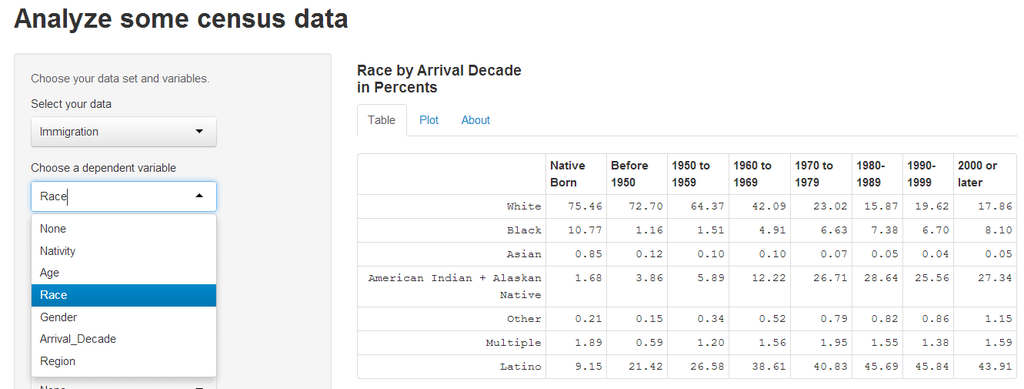

## The Problem

We want students to do sociology and to be comfortable working with data

# but

Comprehensive statistical packages like R, SPSS, SAS and STATA are too complicated to learn outside of a statistics class. You end up teaching the software not the content.

Most online solutions are either too complex, don’t give you the exact data you need, or were written for Netscape or for older desktops.

Spreadsheets work well for some tasks, but they really do not work well for cross tabulation which is a core sociology tool especially in introductory classes.

We need something simple for students and faculty, but that lets us have the exact authentic data we want.

We need an open source, web-based solution.

Try crosstabber: http://elinw.shinyapps.io/crosstabber/

Get the code: https://github.com/elinw/crosstabber

Create your own data sets: https://github.com/elinw/crosstabber-tools

Get your own micro data from Data Ferret: http://dataferrett.census.gov/